# Introduction to Network Science

Structure of networks

Szymon Talaga http://iss.uw.edu.pl/szymon-talaga (Robert Zajonc Institute for Social Studies, University of Warsaw)http://iss.uw.edu.pl  
October 15, 2021

```r
ROOT <- here::here()
DATA <- file.path(ROOT, "data")
UTIL <- file.path(ROOT, "scripts")

source(file.path(UTIL, "prep-dependencies.R"))

knitr::opts_chunk$set(
    echo = TRUE,
    fig.width = 8,
    fig.height = 5
)

# PACKAGE THAT WE WILL USE
library(tidyverse)
library(ggplot2)
library(ggforce)
library(igraph)
library(ggraph)
library(patchwork)
library(latex2exp)

# SET DEFAULT AETHETICS FOR `ggplot2`
theme_set(theme_bw())
```

# Introduction

In this notebook we will get some hands-on experience some of the most important methods for quantifying and analyzing structure of networks beyond simple edge density and degree distribution. We will also learn about the most important null model which is commonly used to construct statistical tests for various network parameters.

In the second part we will discuss a more in-depth analysis of a real-world elite network of Mexican political elites.

## Datasets

In this class in general we will work primarily with the following three real-world networks:

1. **Hyperlinks between US political blogs in 2004.** This is a quite famous dataset representing hyperlink connections between various US political blogs in 2004. Crucially, it also provides information on general political affiliations of the blogs (i.e. republican vs democrat). As such it is a perfect dataset for studying, for instance, homophily and reciprocity in politics-focused mass online communication. It may not be a typical elite network but it gives some interesting snapshot of public discourse concerning political elites. Moreover, it can be argued that some of the most influential bloggers can be considered a part political elites due to the potential for influencing decision-makers and voters alike.
   - It is a directed network with $1490$ nodes and $19090$ so it is relatively large.
2. **Conflict-induced decomposition of a karate club in 1970’s (US).** This is clearly not an elite network, but it is very famous in network science and we will use it to discuss several methods, particularly community detection. It represents associations (e.g. frequent talking outside the class) between members of a karate club in 1970’s in the US, as measured through an in-depth ethnographic observations, in the period when the club had been going through a serious conflict between the main instructor and the main administrator, leading to a decomposition into two opposing camps.
   - It is an undirected network with $34$ nodes and $78$ edges. It comes with edge weights, but very often is analyzed also as an unweighted network.
3. **Association within Mexican political elites in XX century.** It depicts associations — through political, kinship, friendship and business ties — between some of the leading members of Mexican political elites throughout the XX century. It includes metadata indicating whether a given person is of a civilian or military status as well as the year of joining the government. I also extended the metadata for our purposes by adding years of death as well as the number of years of functioning within the elite (the number of years before joining the government and dying or the year of publication of the study which is 1996).
   - It is an undirected network with $35$ nodes and $117$ edges. Note that thanks to time-related metadata it can be also seen as a dynamic network evolving through time. We will try to study it also from this perspective.

All the datasets are already prepared and available in `data` subdirectory. They are saved in the so-called `GML` (Graph Modeling Language) format which is one of popular formats for storing graph data. The data files are also compressed using the GZIP algorithm so they need to be uncompressed first.

# Loading data

Since the data files are compressed we will start by writing a simple function for loading our datasets. Note that in the first chunk we define `DATA` global variable which is a path pointing to the `data` subdirectory.

```r
## HERE WE DEFINE THE FUNCTION FOR READING DATA
##
## NOTE THAT WE USE `datapath` ARGUMENT WITH THE DEFAULT VALUE
## EQUAL TO `DATA` GLOBAL VARIABLE.
## THIS WAY THE FUNCTION CAN BE USED WITHOUT SPECIFYING `datapath` ARG
## EVER TIME, BUT IT CAN BE CUSTOMIZED IF NEEDED.

read_gml <- function(name, datapath = DATA) {
    # define ungzipped connection to the file (so-called file handle)
    # note that we use `open = "rb"` argument to specify that we
    # are opening the file only for reading data and we do this
    # in so-called binary format, since the file is compressed.

    # Add extensions `.gml.gz` to `name` if needed
    if (!str_ends(name, "\\.gml\\.gz")) name <- str_c(name, ".gml.gz")
    # Define path to the particular file we want to open
    # by concatenating `name` to `datapath`.
    fpath <- file.path(datapath, name)
    # Create file handle with GZIP compression
    fh <- gzfile(fpath, open = "rb")
    # Load graph
    G <- read_graph(fh, format = "gml")
    # Return the graph
    G
}
```

# Clustering

A common pattern found in social networks (as well as other types of networks) is known as transitivity or clustering. It is a tendency for nodes connected to the same neighbor to be connected also to each other. In more sociological terms it means that clustering, from a perspective of an individual node, implies that:

> My friends are friends with each other

The clustering coefficient measures exactly this tendency. It is defined in terms of the number of 2-paths with node $i$ at the center (e.g. $j-i-k$) which are close and form a triangle, that is, a 3-cycle (e.g. $j-i-k-j$).

Similarily, we can calculate global clustering coefficient just by counting the fraction of all 2-paths in a network which form triangles.

Clustering is commonly related to the phenomenon of homophily which is the tendency for similar individuals to be likely to be connected to each other. Crucially, high clustering implies a kind of structural similarity between connected nodes as it means that they are likely to share the same neighbors and hence to be embedded in the network in similar ways, or in other words, that they share similar **social positions** within the network.

## Clustering in karate club

```r
G <- read_gml("karate")

## Calculate clustering
transitivity(G, type = "global")
```

```
[1] 0.2556818
```

The global clustering of the karate club network is about $25\%$ meaning that on average one fourth of all 2-paths in the network make triangles. To get some feel for whether this results is high or low we can compare it with the expected clustering in a corresponding ER random graph which is equal simply to edge density.

Later on we will also discuss a better method for such statistical validation.

```r
clu  <- transitivity(G, type = "global")
dens <- edge_density(G)

c(
    "Observed clustering" = clu,
    "ER clustering" = dens,
    "ratio" = clu / dens
)
```

```
Observed clustering       ER clustering               ratio
          0.2556818           0.1390374           1.8389423
```

We see that observed clustering is almost two times higher suggesting that in this network we indeed have a significant tendency for people sharing similar connections. This is in general a typical result for social networks, so we should not be surprised.

We can get a more finely-grained picture of the clustering in the network by studying local clustering coefficients for individual nodes and also relating them to their degrees.

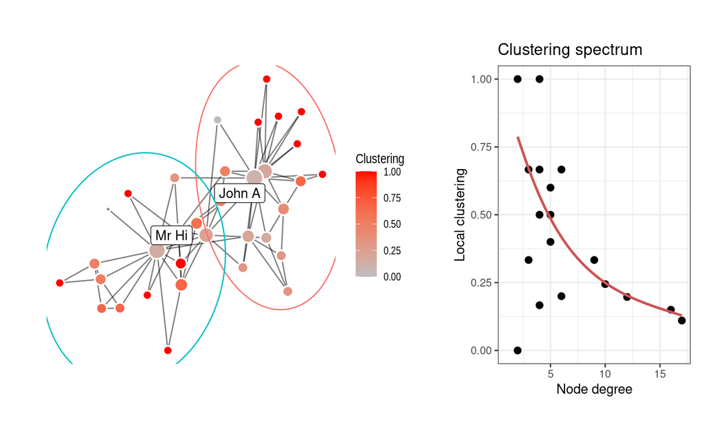

```r
data <- tibble(
    clu = transitivity(G, type = "localundirected"),
    deg = degree(G)
)

# Add clustering and degrees also as attributes
V(G)$clu <- data$clu
V(G)$deg <- data$deg

plt1 <- ggraph(G, layout = "fr") +
    geom_edge_link(alpha = .5) +
    geom_node_point(aes(fill = clu, size = sqrt(deg)), shape = 21L, color = "white", stroke = 1L) +
    geom_node_label(aes(label = ifelse(name %in% c("Mr Hi", "John A"), name, NA_character_)), repel = TRUE) +
    geom_mark_ellipse(aes(x = x, y = y, color = faction)) +
    scale_fill_gradient(low = "gray", high = "red") +
    guides(
        size = "none",
        color = "none"
    ) +
    labs(
        fill = "Clustering"
    ) +
    theme_graph()

plt2 <- ggplot(data, aes(x = deg, y = clu)) +
    geom_point(shape = 21L, fill = "black", color = "white", stroke = 1, size = 3) +
    geom_smooth(method = "gam", color = "indianred3", se = FALSE) +
    labs(
        x = "Node degree",
        y = "Local clustering",
        title = "Clustering spectrum"
    )

# USE `patchwork` PACKAGE TO COMBINE TWO PLOTS SIDE-BY-SIDE
(plt1 | plt2) + plot_layout(widths = c(3, 2))
```

# Community detection

Edge density is just one global parameter, but in many networks local edge densities in different regions can vary greatly. Very often we may be interested in detecting subgroups of nodes belonging to such regions of high edge density. They correspond to parts of the network which are densely connected and cohesive. Such densely connected subgroups are often called **communities** and the process of finding them is known in the literature as **community detection**.

**NOTE.** The notion of community is in general more complex and there are types of communities that may not be defined solely through high local edge density. But for the sake of simplicity let us think about communities as regions of high local edge densities.

One of the most popular, and also very effective in many circumstances, algorithms for community detection is the Girvan-Newman algorithm. It is based on the idea of finding communities by systematic deletion of edges with high betweenness (those through pass most of the shortest paths between different nodes in the network). By deleting such nodes the network is slowly decomposed into disjoint components and then a particular partition yielding most cohesive (modular) communities may be selected.

## Communities in the karate club network

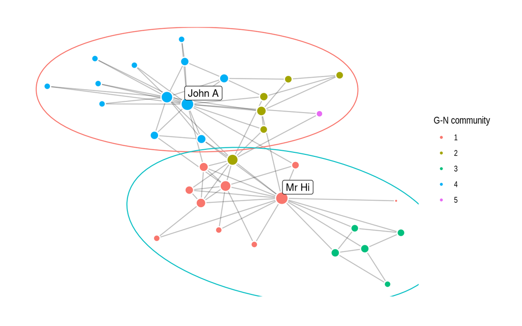

```r
set.seed(101010)
communities <- cluster_edge_betweenness(G, weights = NULL, directed = FALSE)

V(G)$comm <- as.character(communities$membership)

ggraph(G, layout = "fr") +
    geom_edge_link(alpha = .25) +
    geom_node_point(aes(fill = comm, size = sqrt(deg)), shape = 21L, color = "white", stroke = 1) +
    geom_node_label(aes(label = ifelse(name %in% c("Mr Hi", "John A"), name, NA_character_)), repel = TRUE) +
    geom_mark_ellipse(aes(x = x, y = y, color = faction)) +
    guides(
        size = "none",
        color = "none"
    ) +
    labs(
        fill = "G-N community"
    ) +
    theme_graph()
```

Note that the algorithm does not find a perfect partition into two factions. However, the detected communities are mostly contained within specific factions. Therefore, the algorithm detected more finely grained structure while it still identified the large-scale division.

We can check this by using the previous result of our community detection procedure and ask it for a division into only two communities. And as we can see the solution is almost perfect. The algorithm misclassified only one node, which indeed is at the boundary of the two factions.

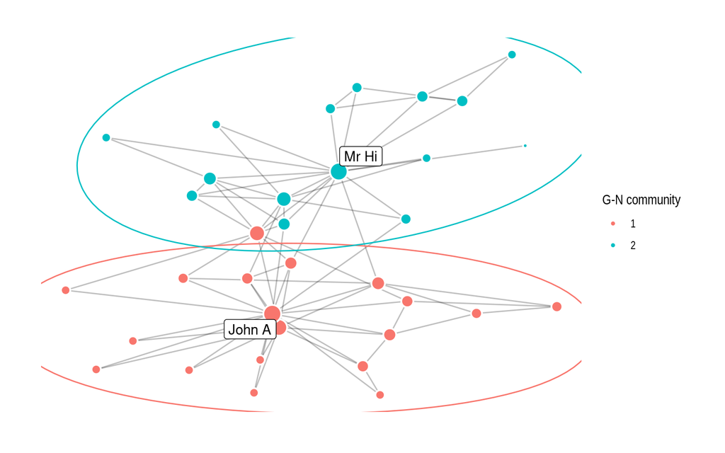

```r
## FIND DIVISION INTO 2 COMMUNITIES
## BASED ON THE PREVIOUS RESULT OF THE G-N ALGORITHM
V(G)$comm2 <- as.character(cut_at(communities, no = 2L))

ggraph(G, layout = "fr") +
    geom_edge_link(alpha = .25) +
    geom_node_point(aes(fill = comm2, size = sqrt(deg)), shape = 21L, color = "white", stroke = 1) +
    geom_node_label(aes(label = ifelse(name %in% c("Mr Hi", "John A"), name, NA_character_)), repel = TRUE) +
    geom_mark_ellipse(aes(x = x, y = y, color = faction)) +
    guides(
        size = "none",
        color = "none"
    ) +
    labs(
        fill = "G-N community"
    ) +
    theme_graph()
```

We can check this by comparing the split into two communities against the known division in two factions directly. And we see that our earlier conclusion is correct. The algorithm missclassified only a single node.

The first detected community clearly corresponds to the faction of John A and the second to the faction of Mr Hi.

```r
table(V(G)$faction, V(G)$comm2)
```

```
          1  2
  John A 18  0
  Mr Hi   1 15
```

We can also study the entire profile of modularity score with respect to the number of communities as detected by the G-N algorithm. In our case we see that the solution with $2$ communities is not much worse than the best solution with $5$ communities. This corroborates our intuition that the algorithm finds the division into two faction correctly, but also allows us to detect more finely-grained subdivisions.

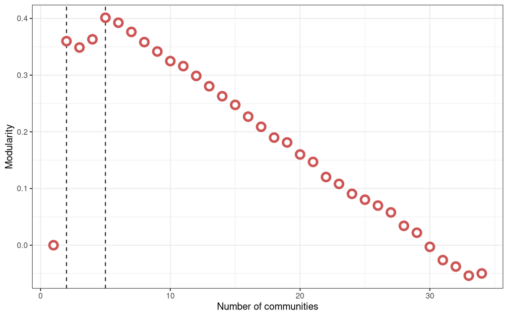

```r
data <- tibble(
    n_comm = 1L:vcount(G),
    modularity = map_dbl(n_comm, ~modularity(G, cut_at(communities, no = .x)))
)

ggplot(data, aes(x = n_comm, y = modularity)) +
    geom_vline(xintercept = c(2L, 5L), linetype = 2L) +
    # geom_line(linetype = 2) +
    geom_point(shape = 21L, color = "indianred3", fill = "white", stroke = 2L, size = 3) +
    labs(
        x = "Number of communities",
        y = "Modularity"
    )
```

**NOTE.** Without going into to much of mathematical details, the modularity score is a function of a particular network and a partition of this network into $k$ groups and it tells us how well separated the two groups are given the structure of the network.

# Small world model

Now we turn to the important question of how is it possible that real networks can have high clustering at short average path lengths at the same time. In general this is an empirical fact as the famous small-world experiment has shown (and multiple later studies confirmed this). Nonetheless, for quite a long time it was not that clear why is that the case.

So the model additionally rewires completely at random some small fraction of edges. This has only marginal effect on the clustering (which remains high) while drastically reduces average path lengths and prevent them from growing fast even in very large networks. Hence, just a tiny bit of randomness can drastically change important global properties of the network (this is conceptually quite similar to how giant components arise in ER model).

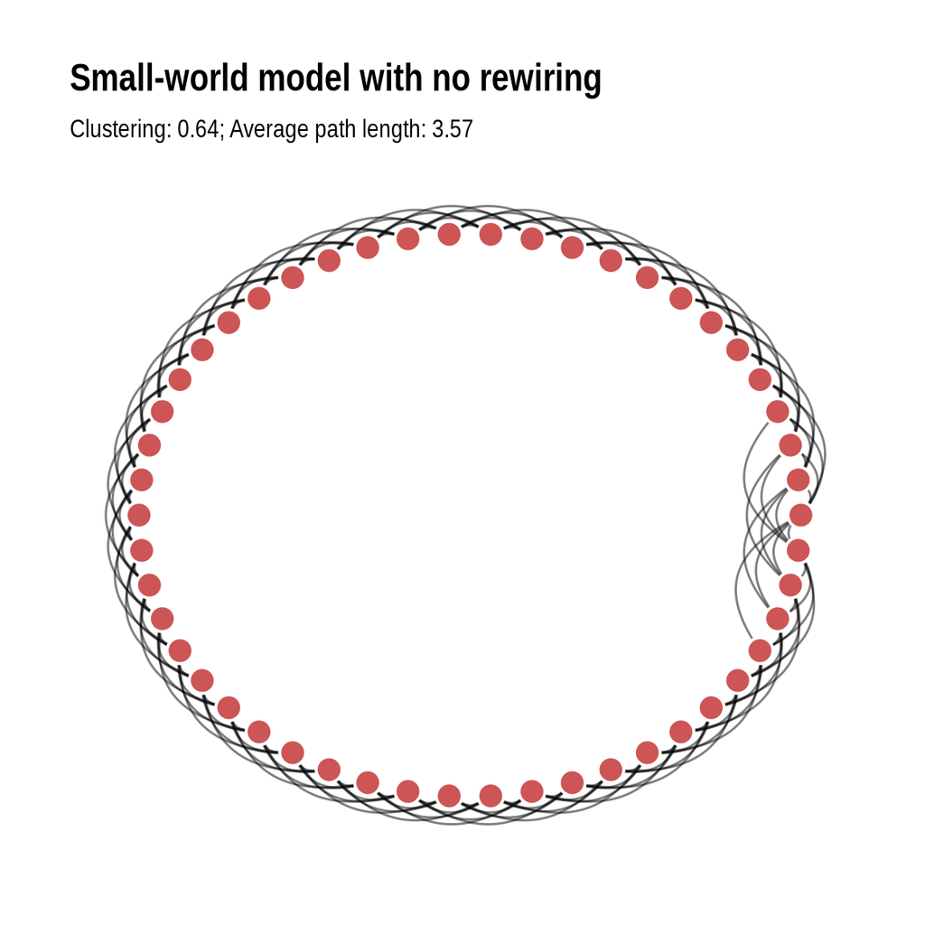

```r
G <- sample_smallworld(1L, size = 50L, nei = 4L, p = 0)

clu <- transitivity(G, type = "global")
apl <- mean_distance(G, directed = FALSE)

ggraph(G, layout = "circle") +
    geom_edge_arc(alpha = .5, strength = -.5) +
    geom_node_point(shape = 21L, fill = "indianred3", color = "white", stroke = 1, size = 5) +
    labs(
        title = "Small-world model with no rewiring",
        subtitle = sprintf("Clustering: %.2f; Average path length: %.2f", clu, apl)
    ) +
    theme_graph()
```

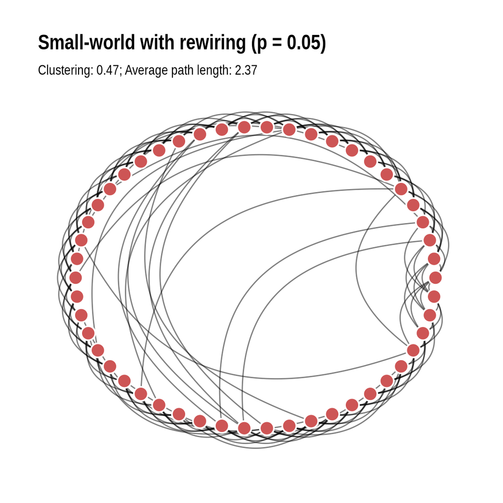

```r
set.seed(303L)

P <- .05
G <- sample_smallworld(1L, size = 50L, nei = 4L, p = P)

clu <- transitivity(G, type = "global")
apl <- mean_distance(G, directed = FALSE)

ggraph(G, layout = "circle") +
    geom_edge_arc(alpha = .5, strength = -.5) +
    geom_node_point(shape = 21L, fill = "indianred3", color = "white", stroke = 1, size = 5) +
    labs(
        title = sprintf("Small-world with rewiring (p = %.2f)", P),
        subtitle = sprintf("Clustering: %.2f; Average path length: %.2f", clu, apl)
    ) +
    theme_graph()
```

The above are just two particular cases. What matter for us most is to see how the model works for networks of different sizes and different values of $p$ (rewiring probability).

```r
N_REPS = 1L
K <- 4L

data <- as_tibble(expand.grid(
    N   = 2^(5:12),
    p   = c(0, .001, .01, .05, .1, .2, .5, 1)
)) %>%
    mutate(
        sw  = map2(N, p, ~rerun(N_REPS, sample_smallworld(1L, size = .x, nei = K, p = .y))),
        clustering = map_dbl(sw, ~mean(map_dbl(.x, transitivity, type = "global"))),
        `average path length` = map_dbl(sw, ~mean(map_dbl(.x, mean_distance)))
    ) %>%
    select(-sw) %>%
    pivot_longer(c(clustering, `average path length`))
```

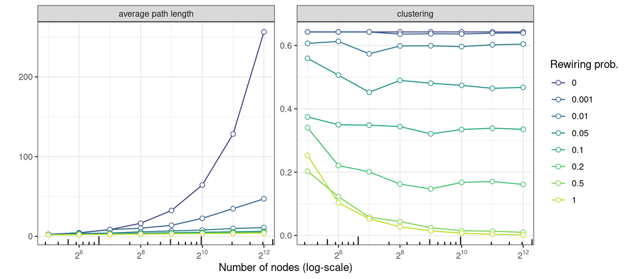

```r
ggplot(data, aes(x = N, y = value, color = as.factor(p))) +
    geom_line() +
    geom_point(shape = 21L, fill = "white", stroke = .5, size = 2) +
    facet_wrap(~name, scales = "free_y") +
    scale_x_log10(
        breaks = scales::trans_breaks("log2", function(x) 2^x),
        labels = scales::trans_format("log2", scales::math_format(2^.x))
    ) +
    annotation_logticks(sides = "b") +
    scale_color_viridis_d(begin = .2, end = .9) +
    labs(
        x = "Number of nodes (log-scale)",
        y = "",
        color = "Rewiring prob."
    )
```

# Assortativity & homophily

Assortativity refers to a statistical tendency that nodes which are similar to each other with respect to some attribute(s) tend to be connected more often than other nodes. In sociology such tendency in the context of social networks is often called **homophily**.

The network of political blogs in the US in 2004 gives us a perfect opportunity to see analysis of assortativity with respect to a qualitative attribute, that is, political affiliation of a glob.

```r
G <- read_gml("polblogs")

# GET ONLY GIANT COMPONENT
# AND SIMPLIFY (REMOVE ANY SELF-LOOPS AND MULTILINKS)
G <- decompose(G)
G <- G[[which.max(map_int(G, vcount))]]
G <- simplify(G)

## Assortativity with respect to political affiliation
## `types` ARGUMENT IS THE VECTOR OF CATEGORIES NODES BELONG TO.
## IT HAS TO BE PASSED AS A VECTOR OF INTEGERS
## THAT IS WHY WE FIRST CONVERT IT TO A FACTOR AND THEN TO INTEGER VECTOR
assortativity_nominal(G, types = as.integer(as.factor(V(G)$affiliation)))
```

```
[1] 0.8228869
```

We see that the level of assortativity, and therefore political homophily, among the blogs is very high (assortativity coefficient is a kind of correlation coefficient so it cannot exceed $1$).

Assortativity can be defined not only with respect to qualitative attributes but also numeric. In particular, very often an important question is whether, in a given network, nodes with high degrees tend to connect to other high degree nodes (positive degree assortativity), or maybe to low degree nodes (negative degree assortativity).

This is what degree assortativity coefficient measures. Technically it is equal just to Pearson linear correlation between degrees of adjacent nodes (minus one, because they “loose” one degree to connect to each other).

```r
assortativity_degree(G, directed = TRUE)
```

```
[1] -0.2309709
```

This assortativity coefficient in our case is moderately negative meaning that blogs often mentioned by other blogs (high degree) are mentioned more often by perihperal (low degree) blogs than other well-connected blogs. To get some understanding of why it is so, we should take a look at the degree distribution of the network.

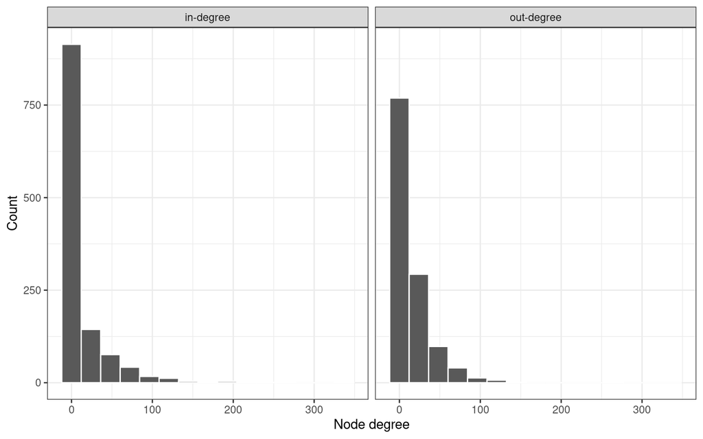

```r
data <- tibble(
    odeg = degree(G, mode = "out"),
    ideg = degree(G, mode = "in")
) %>%
    pivot_longer(c(odeg, ideg)) %>%
    mutate(name = ifelse(name == "ideg", "in-degree", "out-degree"))

ggplot(data, aes(x = value)) +
    geom_histogram(bins = 15, color = "white") +
    facet_wrap(~name, ncol = 2L) +
    labs(
        x = "Node degree",
        y = "Count"
    )
```

Both in- and out-degree distribution are somewhat right-skewed, which means there are much more low-degree nodes than high-degree nodes. Such structure often enforces at least some level of negative degree assortativity as high-degree nodes cannot avoid being linked to lower degree neighbors.

The `polblogs` network is directed so it also makes sense to ask about the level of reciprocity of ties, that is, how often a tie going one way corresponds to a tie in the other direction.

```r
reciprocity(G)
```

```
[1] 0.242574
```

So while assortativity/homophily is very large, the level of reciprocity is rather small.

# Configuration model

As we already established, simple ER random graph model fails us with respect to one very important property, that is, it does not reproduce right-skewed degree distributions characteristic for real-world networks. But there is an extension which does exactly what we need.

**Configuration model** is random graph model which generates networks in which connections are completely random but each node has exactly the degree we want it have. That is, it allows us to generate random graphs which have the same degree sequence as our observed network of interest but which apart from this one property are as random as possible. Technically speaking, configuration model samples all graphs with a given degree sequence uniformly at random.

There are multiple variants of this model and here we will use one which also guarantees that sampled networks are simple (no self-loops or multilinks) and connected. It is very well-suited for randomized undirected, simple, connected networks.

Earlier we discovered that karate club network exhibits clustering coefficient markedly greater than its edge density, suggesting that there is indeed a non-trivial social process at play, which enforces higher than expected abundance of triangles (friends of my friends are my friends etc.).

However, the comparison we made was really done assuming that ER model was the generating process. And since the observed network has right-skewed distribution, we know that this assumption was not correct. But now we can use configuration model to conduct a better statistical test.

The logic is simple. We will use configuration model to sample multiple ($1000$) randomized analogues of our observed graph which all will be connected and have the same degree sequence (so also edge density). Then, we will use them to calculate a null distribution of global clustering coefficients assuming that configuration model was the generating mechanism. And if we find out that the karate club network is still an atypical observation with respect to the null distribution, then it will mean that the degree sequence alone cannot explain its structure, meaning that there must some higher order social process influencing its structure (such as homophily, probably operating within the conflicted groups).

```r
set.seed(1010)

N_REP <- 1000L
G     <- read_gml("karate")
deg   <- degree(G)

# NULL DISTRIBUTION OF GLOBAL CLUSTERING COEFFICIENT
null_clustering <- map_dbl(rerun(N_REP, sample_degseq(deg, method = "vl")), transitivity, type = "global")

# OBSERVED CLUSTERING
obs_clustering <- transitivity(G, type = "global")
# P-VALUE: fraction of null values greater than or equal to the observed value
pvalue <- mean(null_clustering >= obs_clustering)
```

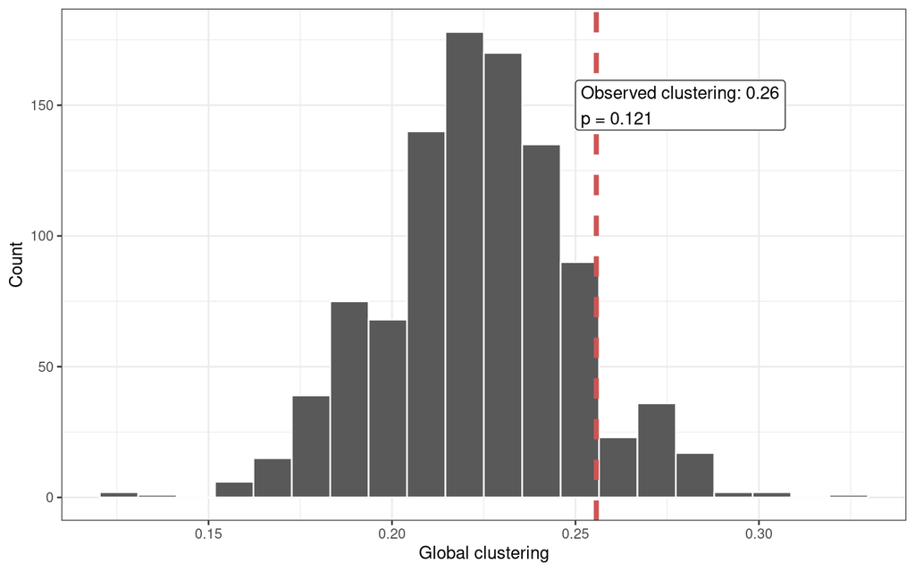

```r
data <- tibble(clustering = null_clustering)

label = sprintf("Observed clustering: %.2f\np = %.3f", obs_clustering, pvalue)

ggplot(data, aes(x = clustering)) +
    geom_histogram(bins = 20L, color = "white") +
    geom_vline(xintercept = obs_clustering, color = "indianred3", linetype = 2L, size = 1.5) +
    annotate("label", x = .25, y = 150L, label = label, hjust = 0) +
    labs(
        x = "Global clustering",
        y = "Count"
    )
```

# Case study: evolution of Mexican political elites in 20th century

We will now try to put everything (more or less) we learned together and conduct a more in-depth study of the structure of the network of associations between members of Mexican political elites in the 20th century.

We will use the fact that this network is inherently dynamic — for each person we know the year he has rised to political importance and the year he died (or not died as the analysis ends at 1996). We also know which politicians are of civilian or military status.

So, as is customary, we will start by visualizing the network.

```r
G <- read_gml("mexican-elites")
V(G)$deg <- degree(G)

## COLORS THAT WE WILL USE TO DENOTE CIVILIANS AND MILITARYMEN
COLORS <- c(
    civilian = "brown",
    military = "darkgreen"
)
```

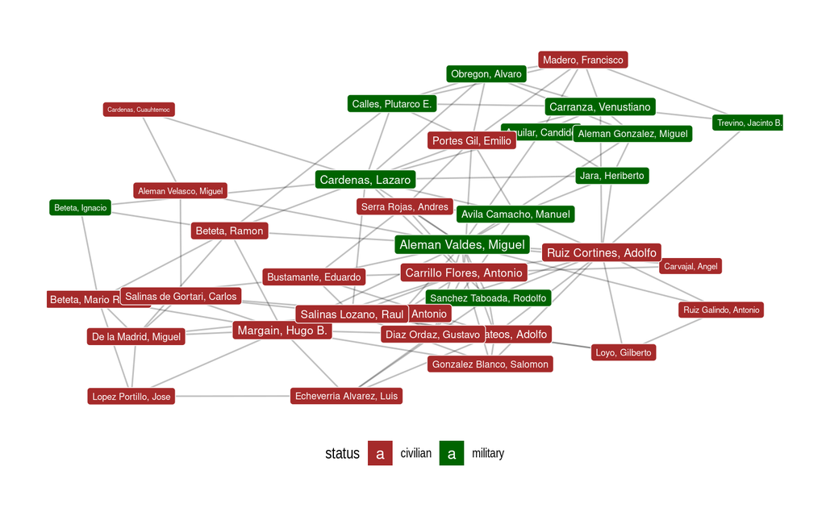

```r
set.seed(1L)

ggraph(G, layout = "fr") +
    geom_edge_link(alpha = .25) +
    geom_node_label(aes(fill = status, size = sqrt(deg), label = name), color = "white") +
    scale_fill_manual(values = COLORS) +
    scale_size_continuous(range = c(1.5, 3)) +
    guides(
        size = "none"
    ) +
    theme_graph() +
    theme(
        legend.position = "bottom"
    )
```

The general structure of the network suggests that we may have some sort of (fuzzy) division between civilian and military actors. However, the current representation is not really reasonable as it completely ignores when any given actor was active in the political field.

But let us first take a look at what the Girvan-Newman community detection algorithm will tell us about the community structure in this “timeless” network.

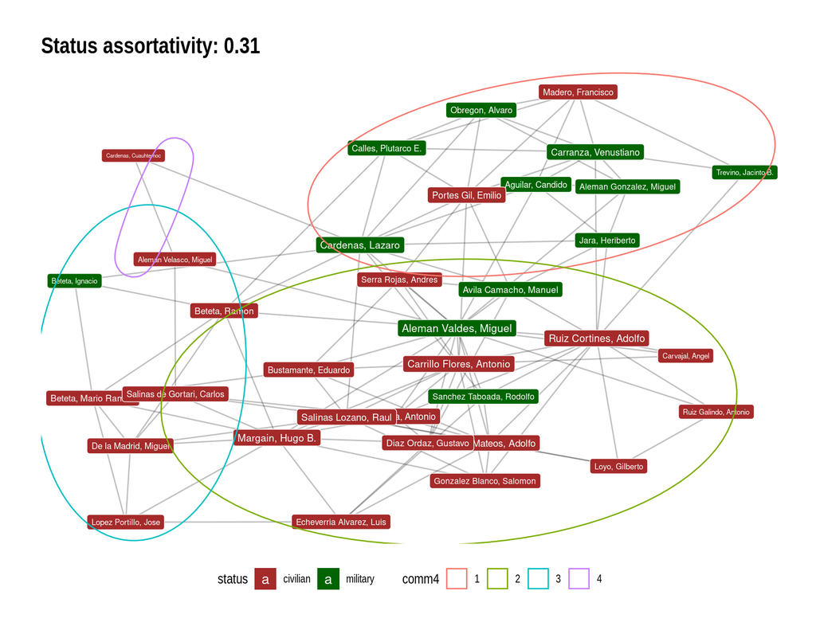

```r
set.seed(1)
communities <- cluster_edge_betweenness(G)

V(G)$comm4 <- as.character(communities$membership)
assort     <- assortativity_nominal(G, as.integer(as.factor(V(G)$status)))

ggraph(G, layout = "fr") +
    geom_edge_link(alpha = .25) +
    geom_node_label(aes(fill = status, size = sqrt(deg), label = name), color = "white") +
    geom_mark_ellipse(aes(x = x, y = y, color = comm4)) +
    scale_fill_manual(values = COLORS) +
    scale_size_continuous(range = c(1.5, 3)) +
    guides(
        size = "none"
    ) +
    labs(
        title = sprintf("Status assortativity: %.2f", assort)
    ) +
    theme_graph() +
    theme(
        legend.position = "bottom"
    )
```

So it seems that our intuition about a division between military and civilian actors may make some sense. But we need to unravel this evolution in time.

We know the start and end year of political life of each individual. So we can use this information to determine when the network changed by new actors being introduced or old removed. And this will allow us to derive a sequence of networks, one for each change, which in turn will allow us to see the evolution of the entire political field.

```r
# DATA FRAME WITH VERTEX ATRIBUTES

data    <- tibble(name = V(G)$name, status = V(G)$status, start = V(G)$start, end = V(G)$end) %>%
    arrange(start, end)

changes <- unique(sort(c(V(G)$start, V(G)$end)))
# COPY OF THE ORIGINAL GRAPH
# WHICH WILL BE USED TO DEFINE DYNAMIC GRAPHS
# ----------------------------------------------
# We will use custom attribute `active` which will be just a boolean vector
# indicating who is active at any given time step (going from change to change)
G_dyn <- G
V(G_dyn)$active <- FALSE
active <- vector(mode = "list", length = length(changes) - 1L)

for (i in seq_along(changes)) {
    change <- changes[i]
    if (change == 1996) next
    V(G_dyn)$active[V(G_dyn)$start == change] <- TRUE
    V(G_dyn)$active[V(G_dyn)$end == change]   <- FALSE

    active[[i]] <- V(G_dyn)$active
}
```

```r
## FUNCTION TO VISUALIZE THE NETWORK AT INDIVIDUAL TIMESTEPS
dynviz <- function(graph, layout, size) {
    ggraph(graph, layout = layout) +
        geom_edge_link(alpha = .25) +
        geom_node_label(aes(
            fill = factor(status, levels = c("civilian", "military")),
            label = name,
            size = sqrt(deg)
        ), color = "white") +
        scale_fill_manual(values = COLORS[levels(factor(V(graph)$status))]) +
        scale_size_continuous(range = range(size)) +
        guides(
            size = "none"
        ) +
        labs(fill = "") +
        theme_graph() +
        theme(
            legend.position = "bottom"
        )
}
```

**NOTE.** You will need to install `gifski` package in order to compile the following chunk to HTML as it contains an animated GIF.

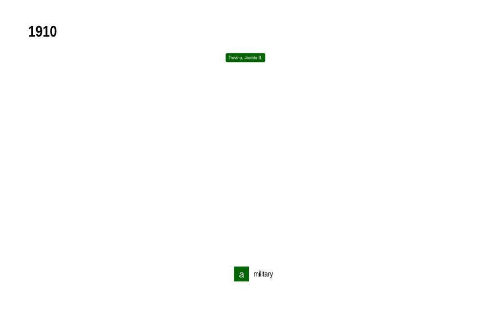

```r
# NODES' POSITIONS CALCULATED ON THE TOTAL NETWORK
# THIS ALLOW TO ANIMATE THE NETWORK WITHOUT NODES JUMPING ALL OVER THE PLACE BETWEEN FRAMES
set.seed(101010)
POS  <- layout_with_fr(G)
XLIM <- range(POS[, 1L])
YLIM <- range(POS[, 2L])
size <- sqrt(V(G)$deg)
# RESCALE IN 1.5 - 3
SIZE <- ((size - min(size)) / (max(size) - min(size)) ) * 1.5 + 1.5


for (i in seq_along(active)) {
    act <- active[[i]]
    change <- changes[i]
    G_dyn  <- induced_subgraph(G, which(act))
    V(G_dyn)$deg <- V(G)$deg[act]
    layout <- matrix(POS[act, ], ncol = 2)  # GET POSITIONS OF ACTIVE NODES and enfore matrix format with 2 columns
    size   <- SIZE[act]
    plot   <- dynviz(G_dyn, layout = layout, size = size) +
        scale_x_continuous(limits = XLIM) +
        scale_y_continuous(limits = YLIM) +
        labs(title = change)
    print(plot)
}
```

Now once we can see the actual evolution we can also try to enhance our understanding by using more quantitative description. In particular, we will be interested in describing the dynamics of the political field in terms of:

1. Size of the network.
2. Fraction of military actors.
3. Edge density.
4. Clustering.
5. Assortativity with respect to the status (military vs. civilian).
6. Modularity of the best split given by the G-N algorithm.

```r
data <- tibble(
    year       = changes[1:length(active)],
    graph      = map(active, ~induced_subgraph(G, which(.x))),
    size       = map_int(graph, vcount) / vcount(G),
    military   = map_dbl(graph, ~mean(V(.x)$status == "military")),
    density    = map_dbl(graph, edge_density),
    clustering = map_dbl(graph, transitivity, type = "global"),
    homophily  = map_dbl(graph, ~assortativity_nominal(.x, types = as.integer(as.factor(V(.x)$status)))),
    modularity = map_dbl(graph, ~{
        if (ecount(.x) <= 0L) return(NA_real_)
        comm <- cluster_edge_betweenness(.x)
        m0 <- modularity(.x, comm$membership)
        # m1 <- modularity(.x, as.integer(as.factor(V(.x)$status)))
        m0
        # m1 / m0
    })
) %>%
    mutate(across(where(is.numeric), ~ifelse(is.nan(.x) | is.infinite(.x), NA, .x))) %>%
    mutate(across(where(rlang::is_integerish), as.integer))
```

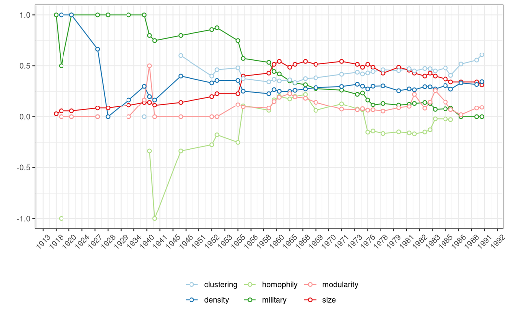

```r
data %>%
    select(-graph) %>%
    pivot_longer(-year) %>%
    ggplot(aes(x = year, y = value, color = name)) +
    geom_line() +
    geom_point(shape = 21L, fill = "white", stroke = .75, size = 1.5) +
    scale_color_brewer(type = "qual", palette = 3L) +
    scale_x_continuous(n.breaks = length(changes), labels = changes) +
    labs(
        x = "",
        y = "",
        color = ""
    ) +
    theme(
        legend.position = "bottom",
        axis.text.x = element_text(angle = 45, vjust = .5, hjust = 0.5)
    )
```

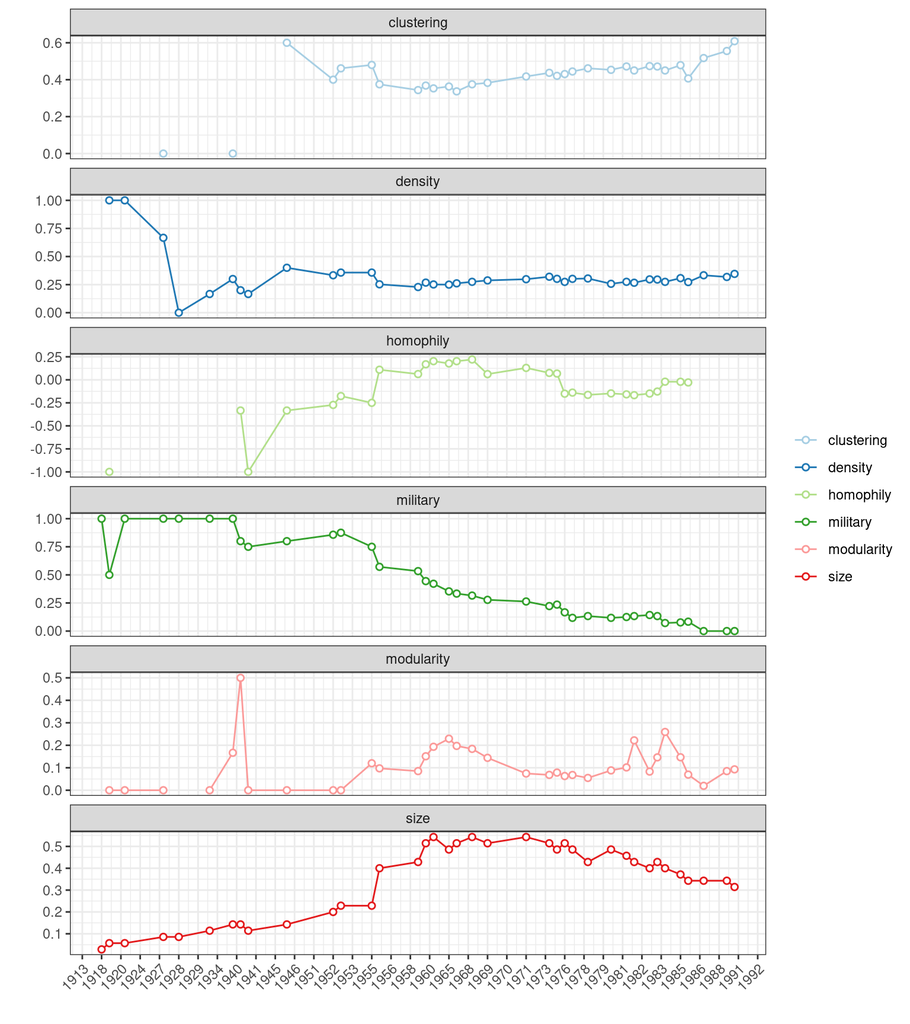

```r
data %>%
    select(-graph) %>%
    pivot_longer(-year) %>%
    ggplot(aes(x = year, y = value, color = name)) +
    geom_line() +
    geom_point(shape = 21L, fill = "white", stroke = .75, size = 1.5) +
    scale_color_brewer(type = "qual", palette = 3L) +
    scale_x_continuous(n.breaks = length(changes), labels = changes) +
    labs(
        x = "",
        y = "",
        color = ""
    ) +
    theme(
        legend.position = "right",
        axis.text.x = element_text(angle = 45, vjust = 1, hjust = 1)
    ) +
    facet_wrap(~name, ncol = 1L, scales = "free_y")
```